# Quantum Oracle

ryamada

2019年8月6日

資料は[こちら](http://people.ece.umn.edu/~ukarpuzc/Karpuzcu_files/QuantumOps.pdf)。

## Rの量子計算パッケージ QuantumOpsのQuantum Oracle関数

量子コンピューティングでは、n量子ビットの入力（input register)をもとに、処理を決め、決めた処理を、m量子ビットの入力(target register)に作用させて、n量子ビットには変化をさせず、m量子ビットを変化させる、という量子演算がある。

- 今、input register(２進法でn桁)の値が x であるとする。
- このxに基づく、処理をf(x)の値が決めるものとする。
- f(x)の値は0以上の整数であるとし、f(x)の値を、target registerのm量子ビットが表す値に加え、その結果の値を処理後のtarget registerの値とする

## 資料の例

[資料](http://people.ece.umn.edu/~ukarpuzc/Karpuzcu_files/QuantumOps.pdf)の例をそのまま示す。

```r
library(QuantumOps)
v <- intket(0,4)
f <- function(x){(x+2) %% 4}
m <- Uf(f,2,2)
print(dirac(v))
```

```
## [1] "1|0000>"
```

```r
print(dirac(U(m,v)))
```

```
## [1] "1|0010>"
```

ここに示した例では、Dirac表記の左側２量子ビット “00”がinput registerで、右側２量子ビット “00” がtarget register。

input register の “00”は整数“0”に相当するから

```r
x <- 0
f(x)
```

```
## [1] 2
```

となって、変化は“2”である。

“2” は2進法で、“10”に相当するから、target registerの“00” に“10”を加えると、“10”

になる。

したがって、処理後は、左側２量子ビットの“00”には変化がなく、右側２量子ビットの“00”が“10”に変わる。

## 丁寧にやる

QuantumOpsパッケージのQuantum Oracle関数 Uf()を少し改変して、中の処理をプリントアウトするように変える。

input registerに対応するループ

について、xの値ごとに、f(x)の値がどうなっているかをプリントアウトし、f(x)の値を2進法表記に変えたbもプリントアウトしている。

(x,f(x))ごとに、target registerに相当する量子ビットに対応する正方行列 g が作られるので、それもプリントアウトする。

```r
my.Uf <- function (fun, n, m)
{
    Um <- matrix(rep(0, (2^(n + m))^2), nrow = 2^(m + n))
    f <- match.fun(fun)
    for (x in 0:(2^n - 1)) {
        b <- as.character(rev(intToBits(f(x))))
        print(b)
        print("x and f(x)")
        print(x)
        print(f(x))
        l <- length(b)
        if (b[l - m + 1] == "00") {
            g <- I()
        }
        else {
            g <- X()
        }
        if (m >= 2) {
            for (j in (l - m + 2):l) {
                if (b[j] == "00") {
                  g <- tensor(g, I())
                }
                else {
                  g <- tensor(g, X())
                }
            }
        }
        print(g)
        Um[((2^m) * x + 1):((2^m) * (x + 1)), ((2^m) * x + 1):((2^m) *
            (x + 1))] <- g
    }
    Um
}
```

いざ実験。

```r
f <- function(x){
    (x + 2) %% 4
}

n <- 2
m <- 2
mm <- my.Uf(f,n,m)
```

```
##  [1] "00" "00" "00" "00" "00" "00" "00" "00" "00" "00" "00" "00" "00" "00"
## [15] "00" "00" "00" "00" "00" "00" "00" "00" "00" "00" "00" "00" "00" "00"
## [29] "00" "00" "01" "00"
## [1] "x and f(x)"
## [1] 0
## [1] 2
##      [,1] [,2] [,3] [,4]
## [1,]    0    0    1    0
## [2,]    0    0    0    1
## [3,]    1    0    0    0
## [4,]    0    1    0    0
##  [1] "00" "00" "00" "00" "00" "00" "00" "00" "00" "00" "00" "00" "00" "00"
## [15] "00" "00" "00" "00" "00" "00" "00" "00" "00" "00" "00" "00" "00" "00"
## [29] "00" "00" "01" "01"
## [1] "x and f(x)"
```

[output cut: 29 more lines]

演算は行列表現があるので、それを視覚化する。

この変換関数f()では、input registerごとにf(x)の値が変わるので、4 個の$4 \times 4$行列はすべて相互に異なっていることが見て取れる。

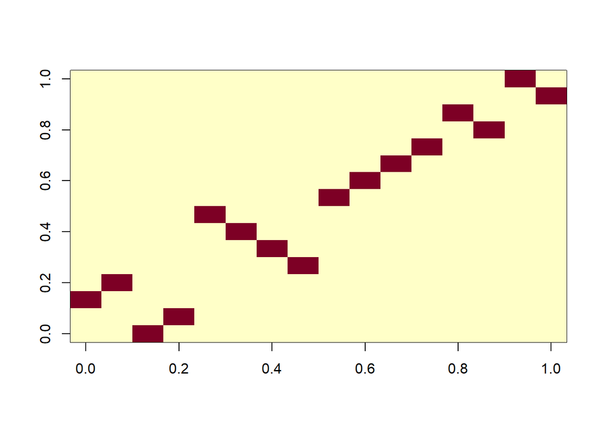

```r
image(mm)
```

input registerと target registerを合わせた量子ビットに対応する、基底ベクトルを作り、それらが演算後、どの基底ベクトルに変化するかを表示する。

```r
mat <- diag(rep(1+0*1i,2^(n+m)))
kets <- list()
for(i in 1:length(mat[,1])){
    kets[[i]] <- matrix(mat[i,],ncol=1)
    #print(kets[[i]])
    print(dirac(kets[[i]]))
    print(dirac(U(mm,kets[[i]])))
    print("---")
}
```

```
## [1] "1|0000>"
## [1] "1|0010>"
## [1] "---"
## [1] "1|0001>"
## [1] "1|0011>"
## [1] "---"
## [1] "1|0010>"
## [1] "1|0000>"
## [1] "---"
## [1] "1|0011>"
## [1] "1|0001>"
## [1] "---"
## [1] "1|0100>"
## [1] "1|0111>"
## [1] "---"
```

[output cut: 33 more lines]

別の関数f(x)でやってみる。

input registerの値によらず、同じ値を返す関数だと、同じ部分行列が並ぶことが分かる

```r
f <- function(x){
    3
}

n <- 2
m <- 2
mm <- my.Uf(f,n,m)
```

```
##  [1] "00" "00" "00" "00" "00" "00" "00" "00" "00" "00" "00" "00" "00" "00"
## [15] "00" "00" "00" "00" "00" "00" "00" "00" "00" "00" "00" "00" "00" "00"
## [29] "00" "00" "01" "01"
## [1] "x and f(x)"
## [1] 0
## [1] 3
##      [,1] [,2] [,3] [,4]
## [1,]    0    0    0    1
## [2,]    0    0    1    0
## [3,]    0    1    0    0
## [4,]    1    0    0    0
##  [1] "00" "00" "00" "00" "00" "00" "00" "00" "00" "00" "00" "00" "00" "00"
## [15] "00" "00" "00" "00" "00" "00" "00" "00" "00" "00" "00" "00" "00" "00"
## [29] "00" "00" "01" "01"
## [1] "x and f(x)"
```

[output cut: 29 more lines]

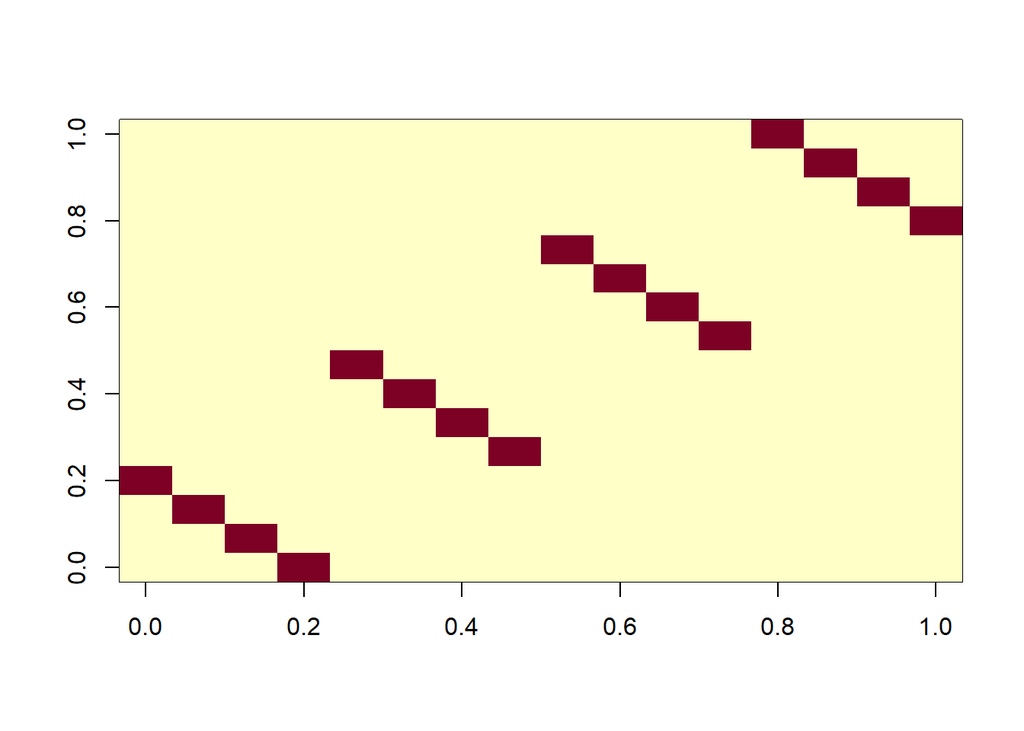

```r
image(mm)
```

```r
mat <- diag(rep(1+0*1i,2^(n+m)))
kets <- list()
for(i in 1:length(mat[,1])){
    kets[[i]] <- matrix(mat[i,],ncol=1)
    #print(kets[[i]])
    print(dirac(kets[[i]]))
    print(dirac(U(mm,kets[[i]])))
    print("---")
}
```

```
## [1] "1|0000>"
## [1] "1|0011>"
## [1] "---"
## [1] "1|0001>"
## [1] "1|0010>"
## [1] "---"
## [1] "1|0010>"
## [1] "1|0001>"
## [1] "---"
## [1] "1|0011>"
## [1] "1|0000>"
## [1] "---"
## [1] "1|0100>"
## [1] "1|0111>"
## [1] "---"
```

[output cut: 33 more lines]

input registerの数とtarget registerの数は異なっていてももちろんよい。

```r
f <- function(x){
    3
}

n <- 2
m <- 3
mm <- my.Uf(f,n,m)
```

```
##  [1] "00" "00" "00" "00" "00" "00" "00" "00" "00" "00" "00" "00" "00" "00"
## [15] "00" "00" "00" "00" "00" "00" "00" "00" "00" "00" "00" "00" "00" "00"
## [29] "00" "00" "01" "01"
## [1] "x and f(x)"
## [1] 0
## [1] 3
##      [,1] [,2] [,3] [,4] [,5] [,6] [,7] [,8]
## [1,]    0    0    0    1    0    0    0    0
## [2,]    0    0    1    0    0    0    0    0
## [3,]    0    1    0    0    0    0    0    0
## [4,]    1    0    0    0    0    0    0    0
## [5,]    0    0    0    0    0    0    0    1
## [6,]    0    0    0    0    0    0    1    0
## [7,]    0    0    0    0    0    1    0    0
## [8,]    0    0    0    0    1    0    0    0
```

[output cut: 45 more lines]

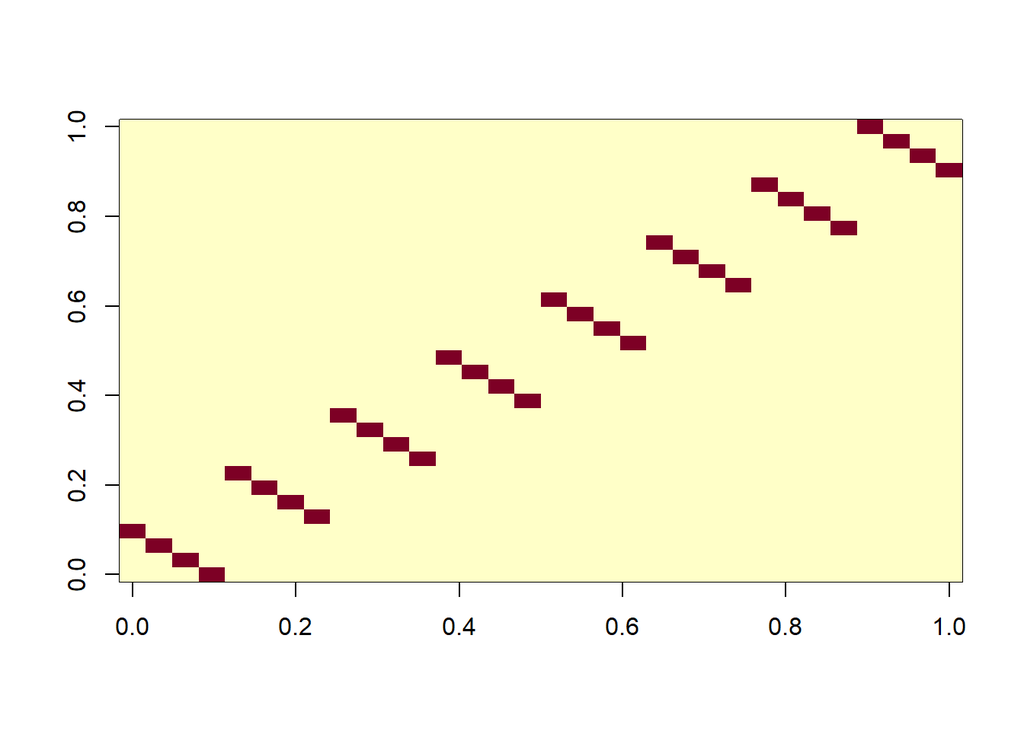

```r
image(mm)
```

```r
mat <- diag(rep(1+0*1i,2^(n+m)))
kets <- list()
for(i in 1:length(mat[,1])){
    kets[[i]] <- matrix(mat[i,],ncol=1)
    #print(kets[[i]])
    print(dirac(kets[[i]]))
    print(dirac(U(mm,kets[[i]])))
    print("---")
}
```

```
## [1] "1|00000>"
## [1] "1|00011>"
## [1] "---"
## [1] "1|00001>"
## [1] "1|00010>"
## [1] "---"
## [1] "1|00010>"
## [1] "1|00001>"
## [1] "---"
## [1] "1|00011>"
## [1] "1|00000>"
## [1] "---"
## [1] "1|00100>"
## [1] "1|00111>"
## [1] "---"
```

[output cut: 81 more lines]

input registerの個数は0でもよい。

その場合は、Uf()関数の仕様から、f(0)の値がすべてのtarget registerに加算されることになる。

```r
f <- function(x){
    x + 30
}

n <- 0
m <- 4
mm <- my.Uf(f,n,m)
```

```
##  [1] "00" "00" "00" "00" "00" "00" "00" "00" "00" "00" "00" "00" "00" "00"
## [15] "00" "00" "00" "00" "00" "00" "00" "00" "00" "00" "00" "00" "00" "01"
## [29] "01" "01" "01" "00"
## [1] "x and f(x)"
## [1] 0
## [1] 30
##       [,1] [,2] [,3] [,4] [,5] [,6] [,7] [,8] [,9] [,10] [,11] [,12] [,13]
##  [1,]    0    0    0    0    0    0    0    0    0     0     0     0     0
##  [2,]    0    0    0    0    0    0    0    0    0     0     0     0     0
##  [3,]    0    0    0    0    0    0    0    0    0     0     0     0     1
##  [4,]    0    0    0    0    0    0    0    0    0     0     0     0     0
##  [5,]    0    0    0    0    0    0    0    0    0     0     1     0     0
##  [6,]    0    0    0    0    0    0    0    0    0     0     0     1     0
##  [7,]    0    0    0    0    0    0    0    0    1     0     0     0     0
##  [8,]    0    0    0    0    0    0    0    0    0     1     0     0     0
```

[output cut: 25 more lines]

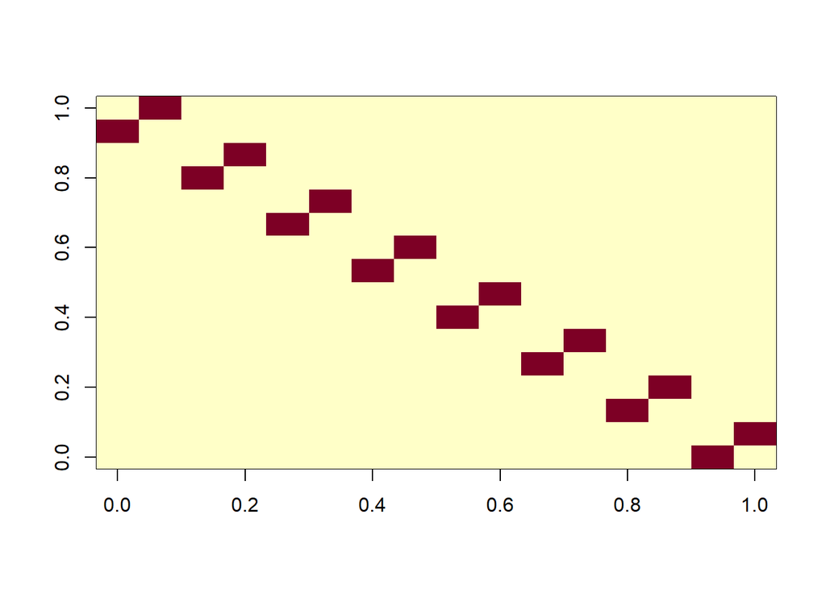

```r
image(mm)
```

```r
mat <- diag(rep(1+0*1i,2^(n+m)))
kets <- list()
for(i in 1:length(mat[,1])){
    kets[[i]] <- matrix(mat[i,],ncol=1)
    #print(kets[[i]])
    print(dirac(kets[[i]]))
    print(dirac(U(mm,kets[[i]])))
    print("---")
}
```

```
## [1] "1|0000>"
## [1] "1|1110>"
## [1] "---"
## [1] "1|0001>"
## [1] "1|1111>"
## [1] "---"
## [1] "1|0010>"
## [1] "1|1100>"
## [1] "---"
## [1] "1|0011>"
## [1] "1|1101>"
## [1] "---"
## [1] "1|0100>"
## [1] "1|1010>"
## [1] "---"
```

[output cut: 33 more lines]